# Seeding Report Card

Thomas Buehrens, WDFW (tbuehrens@dfw.wa.gov),

Last Updated 07/26/2024.

```r
options(width = 100)
knitr::opts_chunk$set(message = FALSE)
set.seed(123)
```

## Functions

Here, we define some functions to fit two forms of Ricker models and a Beverton Holt Model

```r
#function to install or load packages
install_or_load_pack <- function(pack){
  create.pkg <- pack[!(pack %in% installed.packages()[, "Package"])]
  if (length(create.pkg))
    install.packages(create.pkg, dependencies = TRUE,repos = "http://cran.us.r-project.org")
  sapply(pack, require, character.only = TRUE)
}

#logit transform
logit<-function(x){log(x/(1-x))}

#inverse logit transform
ilogit<-function(x){exp(x)/(1+exp(x))}

#fit ricker model with separate hatchery and wild productivity
nll_ricker<-function(par,P,R,S){
  logalpha<-par[1]
  alpha=exp(logalpha)
  loginvbeta<-par[2]
  beta<-1/exp(loginvbeta)
  logitb<-par[3]
  b<-ilogit(logitb)
  logsigma<-par[4]
  sigma<-exp(logsigma)
  R_hat<-(alpha * (1-P) * S + alpha * b * P * S) * exp(-1 * beta * S)
  resid<-log(R_hat)-log(R)
  nll=sum(-1*log(dnorm(resid,mean = 0,sd = sigma)))
}

#fit linearized ricker model with covariate effect on pHOS
nll_ricker2<-function(par,P,R,S){
  logalpha<-par[1]
  alpha=exp(logalpha)
  loginvbeta<-par[2]
  beta<-1/exp(loginvbeta)
  b<-par[3]
  logsigma<-par[4]
  sigma<-exp(logsigma)
  logRS_hat<- log(alpha) - beta * S + b * P
  resid<-logRS_hat-log(R/S)
  nll=sum(-1*log(dnorm(resid,mean = 0,sd = sigma)))
}

#fit beverton-holt model with separate hatchery and wild productivity
nll_bh<-function(par,P,R,S){
  logalpha<-par[1]
  alpha=exp(logalpha)
  logbeta<-par[2]
  beta<-exp(logbeta)
  logitb<-par[3]
  b<-ilogit(logitb)
  logsigma<-par[4]
  sigma<-exp(logsigma)
  R_hat<-(alpha * (1-P) * S + alpha * b * P * S)/(1 + (alpha * (1-P) * S + alpha * b * P * S) /beta)
  resid<-log(R_hat)-log(R)
  nll=sum(-1*log(dnorm(resid,mean = 0,sd = sigma)))
}

#helper function for transforming ricker model params to link scales for estimation (to constrain them to proper domains; e.g., alpha to be positive)
ricker_transform<-function(real_par){
  return(c(
    logalpha=log(real_par[1]),
    loginvbeta=log(1/real_par[2]),
    logitb=logit(real_par[3]),
    logsigma=log(real_par[4])
    )
  )
}

#ricker back transform
ricker_inv_transform<-function(par){
  par<-as.vector(par)
  return(c(
    alpha=exp(par[1]),
    beta=1/exp(par[2]),
    b=ilogit(par[3]),
    sigma=exp(par[4])
    )
  )
}

#helper function for transforming ricker model version 2 params to link scales for estimation (to constrain them to proper domains; e.g., alpha to be positive)
ricker_2_transform<-function(real_par){
  return(c(
    logalpha=log(real_par[1]),
    loginvbeta=log(1/real_par[2]),
    b=real_par[3],
    logsigma=log(real_par[4])
  )
  )
}

#ricker back transform
ricker_2_inv_transform<-function(par){
  par<-as.vector(par)
  return(c(
    alpha=exp(par[1]),
    beta=1/exp(par[2]),
    b=par[3],
    sigma=exp(par[4])
  )
  )
}


bh_transform<-function(real_par){
  return(c(
    logalpha=log(real_par[1]),
    logbeta=log(real_par[2]),
    logitb=logit(real_par[3]),
    logsigma=log(real_par[4])
  )
  )
}

#beverton-holt back transform
bh_inv_transform<-function(par){
  par<-as.vector(par)
  return(c(
    alpha=exp(par[1]),
    beta=exp(par[2]),
    b=ilogit(par[3]),
    sigma=exp(par[4])
  )
  )
}
```

## Load Packages

```r
install_or_load_pack(pack = c("tidyverse","RColorBrewer","kableExtra","gridExtra","viridis"))
```

## Load Data

```r
dat<-read_csv("Tilton_CK_juv_recruits_vs_female_spawners.csv")

dat%>%
  kbl(caption = paste0("Table 1. Example data to fit SR models to develop a seeding report card (in this case Tilton Chinook female hatchery and wild Spawners and the smolt recruits they produced)"),digits =2)%>%
  kable_classic(full_width = F, html_font = "Cambria")
```

Table 1. Example data to fit SR models to develop a seeding report card (in this case Tilton Chinook female hatchery and wild Spawners and the smolt recruits they produced)

| Brood Year | Wild | Hatchery | Recruits |
| --- | --- | --- | --- |
| 2003 | 1743 | 38 | 50074 |
| 2004 | 634 | 38 | 32240 |
| 2005 | 504 | 60 | 70040 |
| 2006 | 43 | 32 | 6245 |
| 2007 | 505 | 82 | 53752 |
| 2008 | 88 | 65 | 4095 |
| 2009 | 463 | 488 | 202399 |
| 2010 | 546 | 1104 | 21084 |
| 2011 | 1460 | 1141 | 147896 |
| 2012 | 899 | 408 | 91251 |
| 2013 | 1406 | 968 | 50612 |
| 2014 | 1151 | 922 | 87162 |
| 2015 | 1446 | 941 | 13662 |
| 2016 | 1623 | 995 | 97000 |
| 2017 | 819 | 934 | 23555 |
| 2018 | 274 | 425 | 34307 |
| 2019 | 297 | 686 | 7658 |

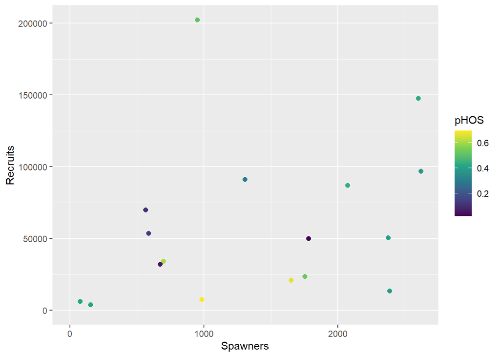

Figure 1. Stock recruit data

```r
dat%<>%
  #filter(`Brood Year`>2010)%>%
  mutate(S=Wild+Hatchery,
         P=Hatchery/S,
         R=Recruits,
         lnrs=log(R/S)
         )%>%
  dplyr::rename(brood_year=`Brood Year`)%>%
  filter(!is.na(P),R>0)

ggplot(dat,aes(x=S,y=R,color=P))+
  geom_point(size=2)+
  xlim(0,NA)+
  ylim(0,NA)+
  labs(x="Spawners",y="Recruits",color="pHOS")+
  scale_color_viridis_c()
```

# Fit SR Models

NOTE: Make sure to check that the convergence value is 0 for each model (i.e., they each converged…otherwise need to change initial values)

Here we will fit three SR models:

First, a modified Ricker model where the total spawners $S$ are multiplied by pHOS $p$ and pNOS $(1-p)$ to derive hatchery and wild spawners and allow us to model their productivities discretely.The recruitment $R$ is function of wild and hatchery spawners where the productivity $\alpha$ for hatchery spawners is multiplied by the relative reproductive success $b$. Density dependence, which is a function of $\beta$ (the inverse of the number of spawners generating the maximum recruitment $Rmax$), is related to total spawner abundance independent of origin: 1)
$$R =
(\alpha (1-p) S + apbS) e^{-\beta S} e^\epsilon$$
where parameters were fit subject to the following constraints:
$$0<\alpha,\sigma, \beta$$
$$0<b<1$$
$$\epsilon \sim normal(0,\sigma)$$

Second, a Ricker model where recruitment $R$ is modeled conventionally as a function of total spawners, but a multiplicative covariate effect $b$ on pHOS $p$ is added to the right hand side of the equation: 2)
$$R = \alpha S e^{-\beta S}
e^{bp} e^\epsilon$$
where parameters were fit subject to the following constraints:
$$0<\alpha,\sigma,
\beta$$
$$\epsilon \sim
normal(0,\sigma)$$

Third, a Beverton-Holt model where recruitment $R$ is modeled as a function of hatchery spawners $pS$ and wild spawners $(1-p)S$ and the productivity of the hatchery spawners is multiplied by their estimated relative reproductive success $b$. In this case there is one maximum recruitment value for the population $\beta$ also known as $Rmax$ but different productivity depending on origin. 3)
$$R = \frac {\alpha (1-p) S +
\alpha p b S}{1 + {\frac {\alpha (1-p) S + \alpha p b S} \beta}
}e^\epsilon$$
where parameters were fit subject to the following constraints:
$$0<\alpha,\sigma,
\beta$$
$$0<b<1$$
$$\epsilon \sim normal(0,\sigma)$$

```r
alpha_guess<-max(exp(dat$lnrs)) #guess alpha parameter
ricker_beta_guess<--lm(lnrs~S,data=dat)$coef[2] #guess beta parameter
bh_beta_guess<-max(dat$Recruits) #guess beta parameter
b_guess<-0.1 #guess Relative Reproductive Success of Hatchery Fish
sigma_guess<-0.4 #guess log-normal residual error sd of SR model


result <- optim(par = ricker_transform(real_par=c(alpha_guess, ricker_beta_guess,b_guess,sigma_guess)), fn = nll_ricker, R = dat$R , S = dat$S,P=dat$P) # par is the initial values of the coefficients
result$par<-ricker_inv_transform(par=result$par) # the maximum likelihood estimates of the coefficients
result$value # the minimum value of the negative log-likelihood
result$convergence # the convergence code (0 means successful convergence)

result2 <- optim(par = ricker_2_transform(real_par=c(alpha_guess, ricker_beta_guess,-(0.2/b_guess),sigma_guess)), fn = nll_ricker2,  R = dat$R , S = dat$S,P=dat$P) # par is the initial values of the coefficients
result2$par<-ricker_2_inv_transform(par=result2$par) # the maximum likelihood estimates of the coefficients
result2$value # the minimum value of the negative log-likelihood
result2$convergence # the convergence code (0 means successful convergence)

result3 <- optim(bh_transform(real_par= c(alpha_guess, bh_beta_guess,b_guess,sigma_guess)), fn = nll_bh,  R = dat$R , S = dat$S,P=dat$P) # par is the initial values of the coefficients
result3$par<-bh_inv_transform(par=result3$par) # the maximum likelihood estimates of the coefficients
result3$value # the minimum value of the negative log-likelihood
result3$convergence # the convergence code (0 means successful convergence)
```

[output not shown]

# Results

```r
params<-tibble(model = c("Ricker", "Ricker version 2", "Beverton-Holt"))%>%
                 bind_cols(bind_rows(result$par,result2$par,result3$par))%>%
                 set_names(c("model","alpha","beta","b","sigma")
                 )%>%
  mutate(Rmax= ifelse(model=="Beverton-Holt",beta,alpha*(1/beta)*exp(-beta*(1/beta))))

params%>%
  kbl(caption = paste0("Table 2. SR params from three models; alpha is max R/S for all models; beta is 1/spawners that produce max recruits for ricker but is equal to max recruits for Beverton-Holt; b is relative reproductive success of hatchery fish for Ricker version 1 and for Beverton-Holt but is the slope of a coefficient for the effect of pHOS on recruitment for Ricker version 2; sigma is log-normal residual error sd; Rmax is maximum recruitment."),digits =4)%>%
  kable_classic(full_width = F, html_font = "Cambria")
```

Table 2. SR params from three models; alpha is max R/S for all models; beta is 1/spawners that produce max recruits for ricker but is equal to max recruits for Beverton-Holt; b is relative reproductive success of hatchery fish for Ricker version 1 and for Beverton-Holt but is the slope of a coefficient for the effect of pHOS on recruitment for Ricker version 2; sigma is log-normal residual error sd; Rmax is maximum recruitment.

| model | alpha | beta | b | sigma | Rmax |
| --- | --- | --- | --- | --- | --- |
| Ricker | 114.8447 | 0.0004 | 0.0000 | 0.7801 | 95506.9 |
| Ricker version 2 | 122.1744 | 0.0004 | -1.6297 | 0.8038 | 106194.3 |
| Beverton-Holt | 112.0747 | 104814.6343 | 0.0000 | 0.7963 | 104814.6 |

```r
fits<-expand_grid(S=seq(1,5000,length.out=100),P=seq(0,0.99,length.out=100))%>%
  mutate(
    Ricker = (result$par[1] * (1-P) * S + result$par[1] * result$par[3] * P * S) * exp(-1 * result$par[2] * S),
    `Ricker version 2` = exp(log(result2$par[1]) - result2$par[2] * S + result2$par[3] * P)*S,#log(P/(1-P))
    `Beverton-Holt` =(result3$par[1] * (1-P) * S + result3$par[1] * result3$par[3] * P * S)/(1 + (result3$par[1] * (1-P) * S + result3$par[1] * result3$par[3] *P * S) /result3$par[2])
  )


fits2<-expand_grid(S=seq(1,5000,length.out=100),P=seq(0,1,length.out=11))%>%
  mutate(
    Ricker = (result$par[1] * (1-P) * S + result$par[1] * result$par[3] * P * S) * exp(-1 * result$par[2] * S),
    `Ricker version 2` = exp(log(result2$par[1]) - result2$par[2] * S + result2$par[3] * P)*S,#log(P/(1-P))
    `Beverton-Holt` =(result3$par[1] * (1-P) * S + result3$par[1] * result3$par[3] * P * S)/(1 + (result3$par[1] * (1-P) * S + result3$par[1] * result3$par[3] *P * S) /result3$par[2])
  )


#color_palette <- brewer.pal(11,"RdBu")

p1<-ggplot(fits,aes(x=S,y=P),alpha=0.5)+
  geom_tile(aes(fill=as.factor(round(Ricker/max(params$Rmax[params$model=="Ricker"]),1))))+
  scale_fill_viridis_d(name = "R/Rmax", guide=guide_legend(override.aes = list(shape=NA)))+
  # scale_fill_manual(values = alpha(color_palette,0.35), name = "R/Rmax",
  #                   guide=guide_legend(override.aes = list(shape=NA)))+
  geom_label(dat,mapping=aes(x=S,y=P),label=dat$brood_year,color="black",fill=NA,label.size=NA,size=3)+
  xlim(0,NA)+
  ylim(0,NA)+
  ylab("pHOS")+
  xlab("Female Spawners")+
  labs(title="Ricker version 1")+
  theme(aspect.ratio = 1)#+
  #theme(legend.position = "none")

p2<-ggplot(fits,aes(x=S,y=P),alpha=0.5)+
  geom_tile(aes(fill=as.factor(round(`Ricker version 2`/max(params$Rmax[params$model=="Ricker version 2"]),1))))+
  scale_fill_viridis_d(name = "R/Rmax", guide=guide_legend(override.aes = list(shape=NA)))+
  # scale_fill_manual(values = alpha(color_palette,0.35), name = "R/Rmax",
  #                   guide=guide_legend(override.aes = list(shape=NA)))+
  geom_label(dat,mapping=aes(x=S,y=P),label=dat$brood_year,color="black",fill=NA,label.size=NA,size=3)+
  xlim(0,NA)+
  ylim(0,NA)+
  ylab("pHOS")+
  xlab("Female Spawners")+
  labs(title="Ricker version 2")+
  theme(aspect.ratio = 1)#+
  #theme(legend.position = "none")


p3<-ggplot(fits,aes(x=S,y=P),alpha=0.5)+
  geom_tile(aes(fill=as.factor(round(`Beverton-Holt`/max(params$Rmax[params$model=="Beverton-Holt"]),1))))+
  scale_fill_viridis_d(name = "R/Rmax", guide=guide_legend(override.aes = list(shape=NA)))+
  # scale_fill_manual(values = alpha(color_palette,0.35), name = "R/Rmax",
  #                   guide=guide_legend(override.aes = list(shape=NA)))+
  geom_label(dat,mapping=aes(x=S,y=P),label=dat$brood_year,color="black",fill=NA,label.size=NA,size=3)+
  xlim(0,NA)+
  ylim(0,NA)+
  ylab("pHOS")+
  xlab("Female Spawners")+
  labs(title="Beverton-Holt")+
  theme(aspect.ratio = 1)#+
  #theme(legend.position = "right")

figure3<-ggplot(
  fits2%>%
    pivot_longer(cols=!c(S,P),names_to = "model",values_to = "R")%>%
    arrange(model,S,P)%>%
    group_by(S,R,P,model)%>%
    left_join(params%>%
                dplyr::select(model,Rmax)
              )%>%
    arrange(model,rev(P),S)

  ,aes(x=S,y=R,group=interaction(model,P)))+
  geom_line(aes(color=as.factor(P)),size=2)+
  facet_wrap(~model, nrow = 1)+
  xlim(0,NA)+
  ylim(0,NA)+
  labs(x="Spawners",y="Recruits",color="pHOS")+
  scale_color_viridis_d()


figure4<-ggplot(
  fits2%>%
    pivot_longer(cols=!c(S,P),names_to = "model",values_to = "R")%>%
    arrange(model,S,P)%>%
    group_by(S,R,P,model)%>%
    left_join(params%>%
                dplyr::select(model,Rmax)
              )%>%
    arrange(model,rev(P),S)

  ,aes(x=S,y=R/Rmax,group=interaction(model,P)))+
  geom_line(aes(color=as.factor(P)),size=2)+
  facet_wrap(~model, nrow = 1)+
  xlim(0,NA)+
  ylim(0,NA)+
  labs(x="Spawners",y="R/Rmax",color="pHOS")+
  scale_color_viridis_d()
```

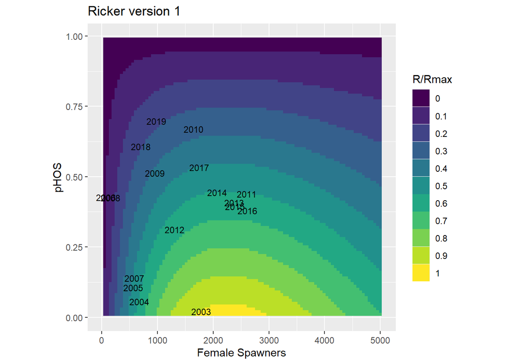

```r
#grid.arrange(p1, p2, p3, ncol = 1, respect=T)
p1
```

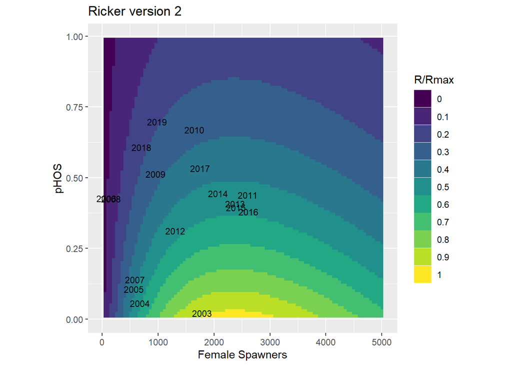

```r
p2
```

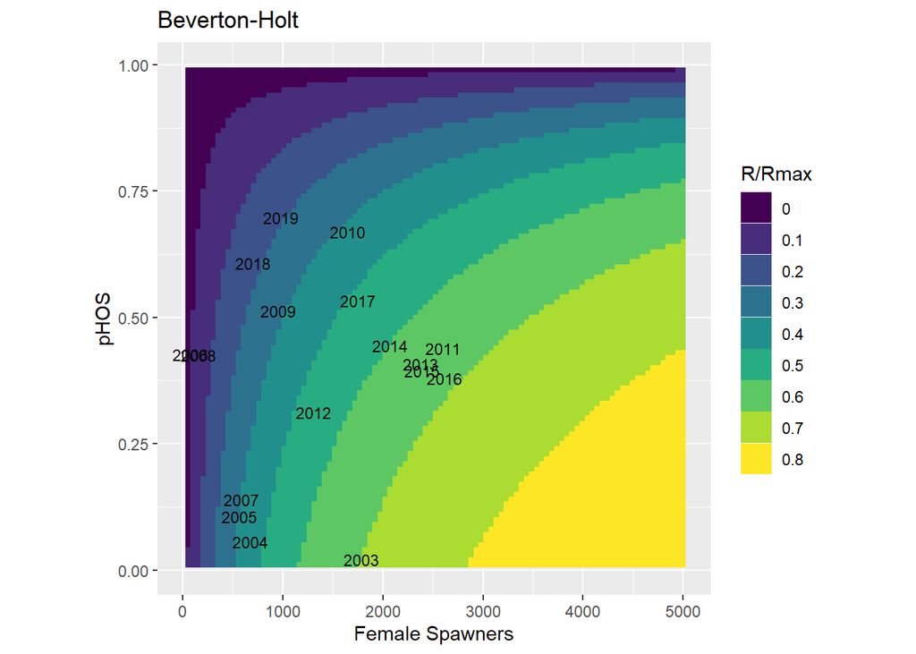

Figure 2.The proportion of full seeding predicted by three stock recruit models as a function of spawner abundance and pHOS. Data points from each year are shown on the graph, depicting the predicted (as opposed to observed) seeding for that year.

```r
p3
```

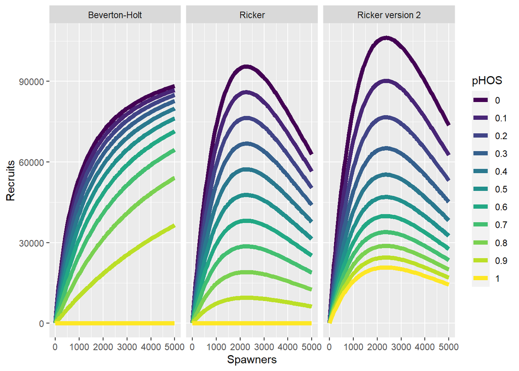

Figure 3.The effect of pHOS on the expected recruitment relationship based on three SR fits.

```r
figure3
```

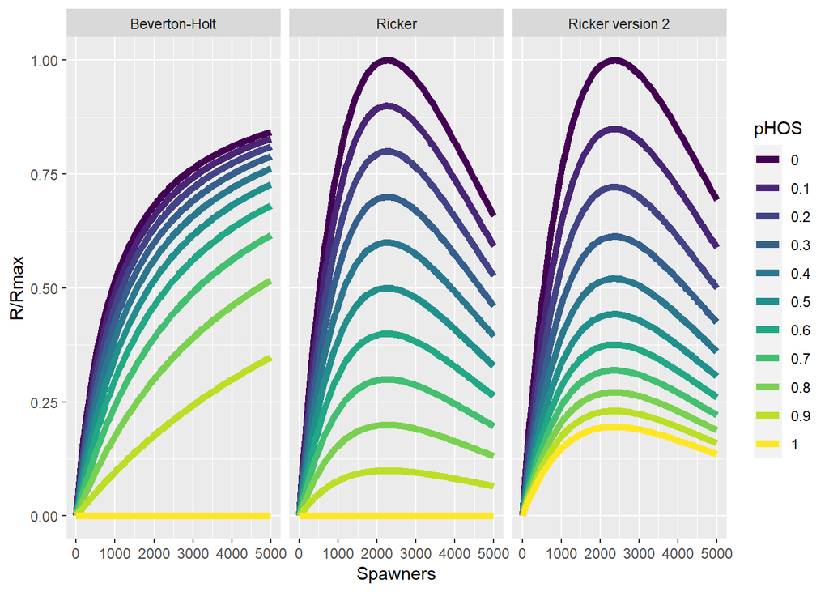

Figure 4.The effect of pHOS on the expected % of full seeding (R/Rmax) depending on spawner abundance and pHOS.

```r
figure4
```

# Possible Use Cases

This analysis may be useful for: 1) empirical estimates of productivity (alpha), capacity (Rmax), and relative reproductive success (b for Ricker version 1 and Beverton-Holt models) 2) to determine what level of seeding is accomplished based on various spawner abundances and pHOS levels (for in-season and post-season evaluations) 3) to ground truth heuristic models like AHA